# Tuberculosis Incidence and BCG Vaccination Coverage (2020)

Tiogouo Tezemene Kevine

21 May, 2025

## Introduction

This report analyzes the relationship between tuberculosis (TB) incidence rates and BCG vaccination coverage across different countries in 2020. We’ll explore the geographical distribution of both indicators and examine their potential relationship through visualizations and statistical analysis.

# World Map of Tuberculosis Incidence Rate per 100,000 people (2020)

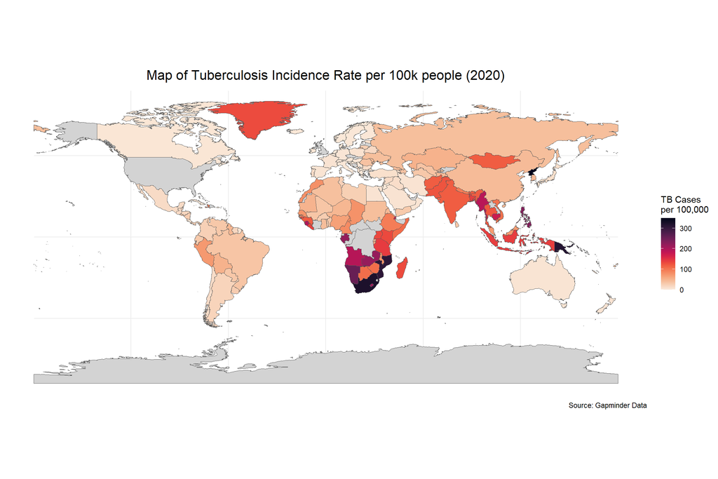

# World Map of BCG Vaccination Coverage (2020)

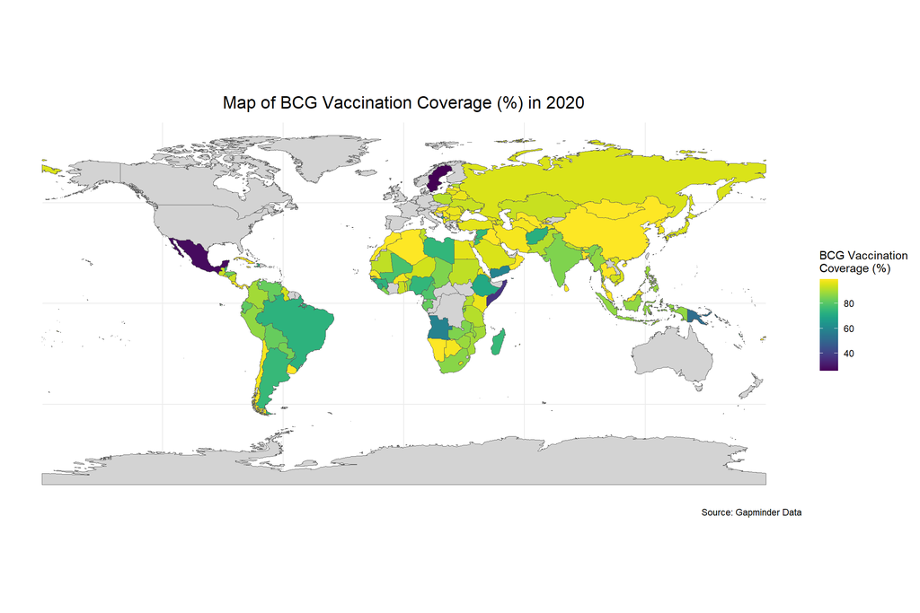

## Relationship Analysis

Let’s examine the relationship between TB incidence and BCG vaccination coverage in 2020.

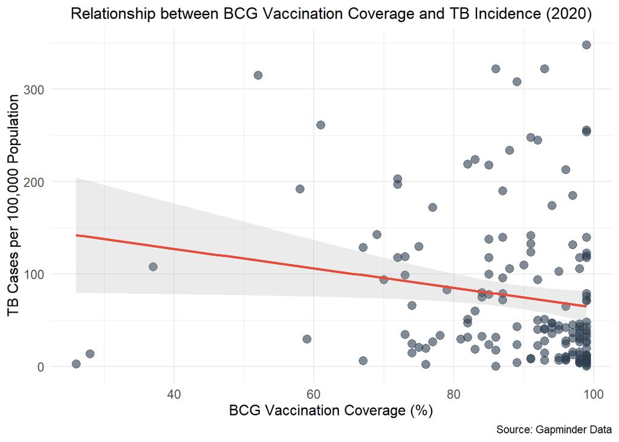

## Interpretation

The correlation coefficient between BCG vaccination coverage and TB incidence in 2020 is -0.171.

Based on the analysis of data from 166 countries in 2020:

1. The average TB incidence rate is 71.1 cases per 100,000 population (median: 39.5)
2. The average BCG vaccination coverage is 88.7% (median: 93%)
3. The correlation coefficient (-0.171) suggests a negative relationship between BCG vaccination coverage and TB incidence rates

The choropleth maps reveal clear geographical patterns: - Higher TB incidence rates are generally observed in parts of Africa and Asia - BCG vaccination coverage is relatively high across most of the developing world - The negative correlation suggests that countries with higher vaccination rates tend to have lower TB incidence, though other factors likely play important roles in this relationship

## Reflection on Interacting with Cursor

Using Cursor has been a valuable experience. One thing that made it easy to work with is how fast and intelligent it is. Cursor helps generate R code, run it, visualize data, interpret results, and even knit documents into R Markdown files — all without needing to use R or write everything manually. This significantly saves time and improves productivity.

However, I faced some challenges as well. I’m still not fully familiar with the platform’s structure, and it doesn’t always feel user-friendly. Sometimes, it doesn’t carry out the exact task requested, and I’m not sure if that’s due to hallucination. I also noticed it can become sluggish when knitting files, especially from the second or third attempt.

What surprised me most is how well Cursor integrates AI assistance directly into the workflow. You can assign tasks in the chat, and Cursor will attempt to make modifications for you. It also provides useful code suggestions during the process.

Through this experience, I learned that Cursor is not just a code editor but also an AI assistant. It helps generate R code for data analysis, visualization, and interpretation without relying on R directly. Overall, it’s a great tool for time management and productivity.